# Cervical Cancer Classification

rbabaei

4/1/2020

## Introduction

The ‘Hospital Universitario de Caracas’ in Caracas, Venezuela, has provided a dataset comprising of demographic information, habits, and historic medical records of 858 patients. Here the risk factors related to cervical cancer are going to be analysed, and a classification model based on provided information will be produced. The original data is accessible on : https://archive.ics.uci.edu/ml/datasets/Cervical+cancer+%28Risk+Factors%29#.

Please consider the citation quote as: “Kelwin Fernandes, Jaime S. Cardoso, and Jessica Fernandes. ‘Transfer Learning with Partial Observability Applied to Cervical Cancer Screening.’ Iberian Conference on Pattern Recognition and Image Analysis. Springer International Publishing, 2017.”.

## Data aquiry and setup

First of all we load the data to the workplace and require the libraries.

```r
library(purrr)
library(caret)
library(ggplot2)
library(ggcorrplot)
library(dplyr)
library(xgboost)
library(VIM)
library(missForest)
library(doParallel)
library(cowplot)
rawData <- read.csv("risk_factors_cervical_cancer.csv", header = T)
str(rawData)
```

```
## 'data.frame':    858 obs. of  36 variables:
##  $ Age                               : int  18 15 34 52 46 42 51 26 45 44 ...
##  $ Number.of.sexual.partners         : Factor w/ 13 levels "?","1.0","10.0",..: 8 2 2 9 7 7 7 2 2 7 ...
##  $ First.sexual.intercourse          : Factor w/ 22 levels "?","10.0","11.0",..: 7 6 1 8 13 15 9 18 12 7 ...
##  $ Num.of.pregnancies                : Factor w/ 12 levels "?","0.0","1.0",..: 3 3 3 8 8 6 10 7 9 1 ...
##  $ Smokes                            : Factor w/ 3 levels "?","0.0","1.0": 2 2 2 3 2 2 3 2 2 3 ...
##  $ Smokes..years.                    : Factor w/ 31 levels "?","0.0","0.16",..: 2 2 2 25 2 2 24 2 2 6 ...
##  $ Smokes..packs.year.               : Factor w/ 63 levels "?","0.0","0.001",..: 2 2 2 51 2 2 49 2 2 44 ...
##  $ Hormonal.Contraceptives           : Factor w/ 3 levels "?","0.0","1.0": 2 2 2 3 3 2 2 3 2 2 ...
##  $ Hormonal.Contraceptives..years.   : Factor w/ 41 levels "?","0.0","0.08",..: 2 2 2 31 22 2 2 26 2 2 ...
##  $ IUD                               : Factor w/ 3 levels "?","0.0","1.0": 2 2 2 2 2 2 3 3 2 1 ...
##  $ IUD..years.                       : Factor w/ 27 levels "?","0.0","0.08",..: 2 2 2 2 2 2 25 25 2 1 ...
##  $ STDs                              : Factor w/ 3 levels "?","0.0","1.0": 2 2 2 2 2 2 2 2 2 2 ...
##  $ STDs..number.                     : Factor w/ 6 levels "?","0.0","1.0",..: 2 2 2 2 2 2 2 2 2 2 ...
##  $ STDs.condylomatosis               : Factor w/ 3 levels "?","0.0","1.0": 2 2 2 2 2 2 2 2 2 2 ...
```

[output cut: 22 more lines]

## Data cleaning

As we see most of the variables are not in correct format, which needs to be done first.

```r
cols.num <- c(names(rawData[c(2:4,6,7,9,11,13,26,27,28)]))
rawData[cols.num] <- sapply(rawData[cols.num], as.numeric)

cols.num <- c(names(rawData[29:36]))
rawData[,cols.num] <- lapply(rawData[,cols.num], factor)
str(rawData)
```

```
## 'data.frame':    858 obs. of  36 variables:
##  $ Age                               : int  18 15 34 52 46 42 51 26 45 44 ...
##  $ Number.of.sexual.partners         : num  8 2 2 9 7 7 7 2 2 7 ...
##  $ First.sexual.intercourse          : num  7 6 1 8 13 15 9 18 12 7 ...
##  $ Num.of.pregnancies                : num  3 3 3 8 8 6 10 7 9 1 ...
##  $ Smokes                            : Factor w/ 3 levels "?","0.0","1.0": 2 2 2 3 2 2 3 2 2 3 ...
##  $ Smokes..years.                    : num  2 2 2 25 2 2 24 2 2 6 ...
##  $ Smokes..packs.year.               : num  2 2 2 51 2 2 49 2 2 44 ...
##  $ Hormonal.Contraceptives           : Factor w/ 3 levels "?","0.0","1.0": 2 2 2 3 3 2 2 3 2 2 ...
##  $ Hormonal.Contraceptives..years.   : num  2 2 2 31 22 2 2 26 2 2 ...
##  $ IUD                               : Factor w/ 3 levels "?","0.0","1.0": 2 2 2 2 2 2 3 3 2 1 ...
##  $ IUD..years.                       : num  2 2 2 2 2 2 25 25 2 1 ...
##  $ STDs                              : Factor w/ 3 levels "?","0.0","1.0": 2 2 2 2 2 2 2 2 2 2 ...
##  $ STDs..number.                     : num  2 2 2 2 2 2 2 2 2 2 ...
##  $ STDs.condylomatosis               : Factor w/ 3 levels "?","0.0","1.0": 2 2 2 2 2 2 2 2 2 2 ...
```

[output cut: 22 more lines]

```r
rm(cols.num)
```

The missing values are defined as “?”. We’ll replace them with NA.

```r
idmiss <- rawData == "?"
is.na(rawData) <- idmiss
rm(idmiss)
str(rawData)
```

```
## 'data.frame':    858 obs. of  36 variables:
##  $ Age                               : int  18 15 34 52 46 42 51 26 45 44 ...
##  $ Number.of.sexual.partners         : num  8 2 2 9 7 7 7 2 2 7 ...
##  $ First.sexual.intercourse          : num  7 6 1 8 13 15 9 18 12 7 ...
##  $ Num.of.pregnancies                : num  3 3 3 8 8 6 10 7 9 1 ...
##  $ Smokes                            : Factor w/ 3 levels "?","0.0","1.0": 2 2 2 3 2 2 3 2 2 3 ...
##  $ Smokes..years.                    : num  2 2 2 25 2 2 24 2 2 6 ...
##  $ Smokes..packs.year.               : num  2 2 2 51 2 2 49 2 2 44 ...
##  $ Hormonal.Contraceptives           : Factor w/ 3 levels "?","0.0","1.0": 2 2 2 3 3 2 2 3 2 2 ...
##  $ Hormonal.Contraceptives..years.   : num  2 2 2 31 22 2 2 26 2 2 ...
##  $ IUD                               : Factor w/ 3 levels "?","0.0","1.0": 2 2 2 2 2 2 3 3 2 NA ...
##  $ IUD..years.                       : num  2 2 2 2 2 2 25 25 2 1 ...
##  $ STDs                              : Factor w/ 3 levels "?","0.0","1.0": 2 2 2 2 2 2 2 2 2 2 ...
##  $ STDs..number.                     : num  2 2 2 2 2 2 2 2 2 2 ...
##  $ STDs.condylomatosis               : Factor w/ 3 levels "?","0.0","1.0": 2 2 2 2 2 2 2 2 2 2 ...
```

[output cut: 22 more lines]

There are factor variables with only one level plus NA, which are not usefull for analysis. In addition, the “?” has been defined as a category. To fix it, we apply factor to the data once more.

```r
rawData$STDs.cervical.condylomatosis <- NULL
rawData$STDs.AIDS <- NULL

factor_index <- which(sapply(rawData[1:23], is.factor))
name_index <- names(rawData[factor_index])

rawData[name_index] <- lapply(rawData[name_index], factor)
str(rawData)
```

```
## 'data.frame':    858 obs. of  34 variables:
##  $ Age                               : int  18 15 34 52 46 42 51 26 45 44 ...
##  $ Number.of.sexual.partners         : num  8 2 2 9 7 7 7 2 2 7 ...
##  $ First.sexual.intercourse          : num  7 6 1 8 13 15 9 18 12 7 ...
##  $ Num.of.pregnancies                : num  3 3 3 8 8 6 10 7 9 1 ...
##  $ Smokes                            : Factor w/ 2 levels "0.0","1.0": 1 1 1 2 1 1 2 1 1 2 ...
##  $ Smokes..years.                    : num  2 2 2 25 2 2 24 2 2 6 ...
##  $ Smokes..packs.year.               : num  2 2 2 51 2 2 49 2 2 44 ...
##  $ Hormonal.Contraceptives           : Factor w/ 2 levels "0.0","1.0": 1 1 1 2 2 1 1 2 1 1 ...
##  $ Hormonal.Contraceptives..years.   : num  2 2 2 31 22 2 2 26 2 2 ...
##  $ IUD                               : Factor w/ 2 levels "0.0","1.0": 1 1 1 1 1 1 2 2 1 NA ...
##  $ IUD..years.                       : num  2 2 2 2 2 2 25 25 2 1 ...
##  $ STDs                              : Factor w/ 2 levels "0.0","1.0": 1 1 1 1 1 1 1 1 1 1 ...
##  $ STDs..number.                     : num  2 2 2 2 2 2 2 2 2 2 ...
##  $ STDs.condylomatosis               : Factor w/ 2 levels "0.0","1.0": 1 1 1 1 1 1 1 1 1 1 ...
```

[output cut: 20 more lines]

```r
rm(factor_index, name_index)
```

### Imputation

Before we go ahead to anaylse the data, we need to handle the missing values. We will map the missing values by variables in a table, and plot them to depict their distribution.

```r
data.frame(map(rawData, ~sum(is.na(.)))) # 14 variables including NAs
```

```
##   Age Number.of.sexual.partners First.sexual.intercourse Num.of.pregnancies
## 1   0                         0                        0                  0
##   Smokes Smokes..years. Smokes..packs.year. Hormonal.Contraceptives
## 1     13              0                   0                     108
##   Hormonal.Contraceptives..years. IUD IUD..years. STDs STDs..number.
## 1                               0 117           0  105             0
##   STDs.condylomatosis STDs.vaginal.condylomatosis
## 1                 105                         105
##   STDs.vulvo.perineal.condylomatosis STDs.syphilis
## 1                                105           105
##   STDs.pelvic.inflammatory.disease STDs.genital.herpes
## 1                              105                 105
##   STDs.molluscum.contagiosum STDs.HIV STDs.Hepatitis.B STDs.HPV
## 1                        105      105              105      105
##   STDs..Number.of.diagnosis STDs..Time.since.first.diagnosis
## 1                         0                                0
##   STDs..Time.since.last.diagnosis Dx.Cancer Dx.CIN Dx.HPV Dx Hinselmann
## 1                               0         0      0      0  0          0
##   Schiller Citology Biopsy
## 1        0        0      0
```

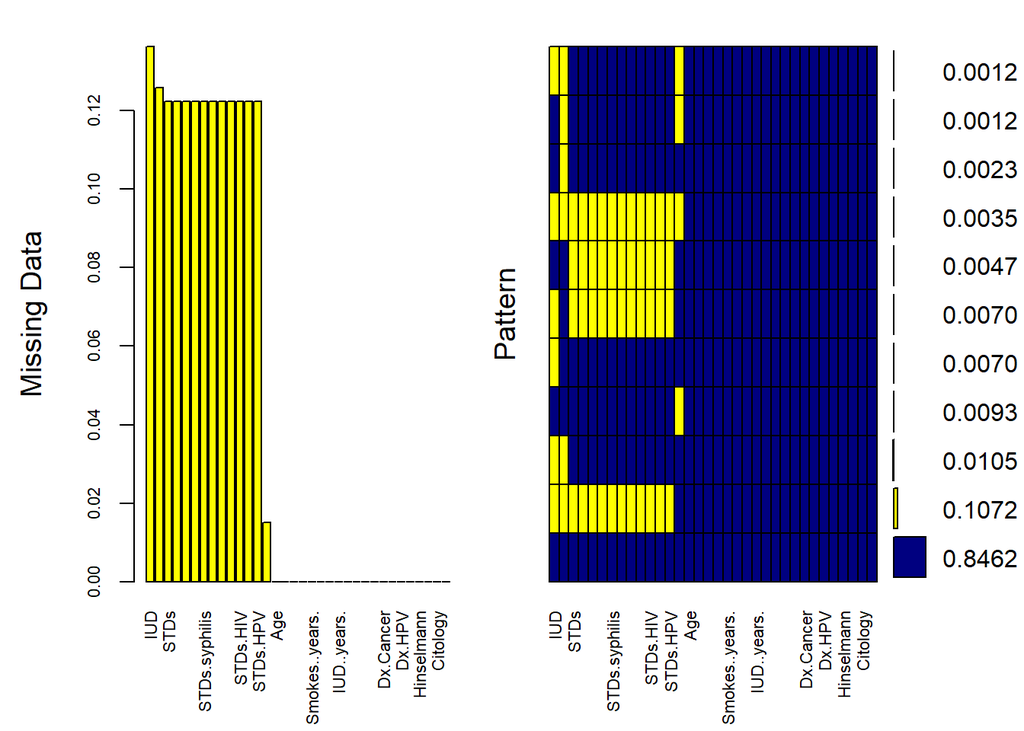

```
##
##  Variables sorted by number of missings:
##                            Variable      Count
##                                 IUD 0.13636364
##             Hormonal.Contraceptives 0.12587413
##                                STDs 0.12237762
##                 STDs.condylomatosis 0.12237762
##         STDs.vaginal.condylomatosis 0.12237762
##  STDs.vulvo.perineal.condylomatosis 0.12237762
##                       STDs.syphilis 0.12237762
##    STDs.pelvic.inflammatory.disease 0.12237762
##                 STDs.genital.herpes 0.12237762
##          STDs.molluscum.contagiosum 0.12237762
##                            STDs.HIV 0.12237762
##                    STDs.Hepatitis.B 0.12237762
##                            STDs.HPV 0.12237762
##                              Smokes 0.01515152
##                                 Age 0.00000000
##           Number.of.sexual.partners 0.00000000
##            First.sexual.intercourse 0.00000000
##                  Num.of.pregnancies 0.00000000
##                      Smokes..years. 0.00000000
##                 Smokes..packs.year. 0.00000000
##     Hormonal.Contraceptives..years. 0.00000000
##                         IUD..years. 0.00000000
##                       STDs..number. 0.00000000
##           STDs..Number.of.diagnosis 0.00000000
##    STDs..Time.since.first.diagnosis 0.00000000
##     STDs..Time.since.last.diagnosis 0.00000000
##                           Dx.Cancer 0.00000000
##                              Dx.CIN 0.00000000
##                              Dx.HPV 0.00000000
##                                  Dx 0.00000000
##                          Hinselmann 0.00000000
##                            Schiller 0.00000000
##                            Citology 0.00000000
##                              Biopsy 0.00000000
```

```r
miss_plot <- aggr(rawData, col = c("navyblue", "yellow"),
                  numbers = TRUE, sortVars = TRUE,
                  labels = names(rawData),
                  cex.axis = 0.7, gap = 3,
                  ylab = c("Missing Data", "Pattern"))
```

Now, we will impute the missing values with the help of missForest package.

```r
set.seed(145)

# run parallel iteration
registerDoParallel(cores = 3)
impute_forest <- missForest(data.frame(rawData),maxiter = 10 ,ntree = 100, parallelize = "forests")
```

```
##   missForest iteration 1 in progress...done!
##   missForest iteration 2 in progress...done!
##   missForest iteration 3 in progress...done!
```

```r
stopImplicitCluster()

# check imputation error
impute_forest$OOBerror # the imputation is done for categorical variables with 0.2% error which is well acceptable
```

```
##       NRMSE         PFC
## 0.000000000 0.002471551
```

```r
imputed_data <- impute_forest$ximp
```

## Exploratory Data Analysis

Now, our data frame is complete, without any missing values. We can take a look at its summary, and check for the correlation between the variables.

```r
summary(imputed_data)
```

```
##       Age        Number.of.sexual.partners First.sexual.intercourse
##  Min.   :13.00   Min.   : 1.000            Min.   : 1.000
##  1st Qu.:20.00   1st Qu.: 2.000            1st Qu.: 7.000
##  Median :25.00   Median : 5.000            Median : 9.000
##  Mean   :26.82   Mean   : 5.262            Mean   : 8.928
##  3rd Qu.:32.00   3rd Qu.: 7.000            3rd Qu.:10.000
##  Max.   :84.00   Max.   :13.000            Max.   :22.000
##  Num.of.pregnancies Smokes    Smokes..years.   Smokes..packs.year.
##  Min.   : 1.000     0.0:735   Min.   : 1.000   Min.   : 1.000
##  1st Qu.: 3.000     1.0:123   1st Qu.: 2.000   1st Qu.: 2.000
##  Median : 6.000               Median : 2.000   Median : 2.000
##  Mean   : 5.241               Mean   : 4.118   Mean   : 6.059
##  3rd Qu.: 7.000               3rd Qu.: 2.000   3rd Qu.: 2.000
##  Max.   :12.000               Max.   :31.000   Max.   :63.000
##  Hormonal.Contraceptives Hormonal.Contraceptives..years.  IUD
##  0.0:377                 Min.   : 1.00                   0.0:775
##  1.0:481                 1st Qu.: 2.00                   1.0: 83
##                          Median : 6.00
##                          Mean   :12.86
##                          3rd Qu.:26.00
##                          Max.   :41.00
##   IUD..years.      STDs     STDs..number.   STDs.condylomatosis
##  Min.   : 1.000   0.0:779   Min.   :1.000   0.0:814
##  1st Qu.: 2.000   1.0: 79   1st Qu.:2.000   1.0: 44
##  Median : 2.000             Median :2.000
##  Mean   : 3.494             Mean   :2.033
##  3rd Qu.: 2.000             3rd Qu.:2.000
##  Max.   :27.000             Max.   :6.000
##  STDs.vaginal.condylomatosis STDs.vulvo.perineal.condylomatosis STDs.syphilis
##  0.0:854                     0.0:815                            0.0:840
##  1.0:  4                     1.0: 43                            1.0: 18
##
##
##
##
##  STDs.pelvic.inflammatory.disease STDs.genital.herpes
##  0.0:857                          0.0:857
##  1.0:  1                          1.0:  1
##
##
```

[output cut: 15 more lines]

```
##  Max.   :3.00000           Max.   :19.000
##  STDs..Time.since.last.diagnosis Dx.Cancer Dx.CIN  Dx.HPV  Dx      Hinselmann
##  Min.   : 1.000                  0:840     0:849   0:840   0:834   0:823
##  1st Qu.: 1.000                  1: 18     1:  9   1: 18   1: 24   1: 35
##  Median : 1.000
##  Mean   : 1.718
##  3rd Qu.: 1.000
##  Max.   :19.000
##  Schiller Citology Biopsy
##  0:784    0:814    0:803
##  1: 74    1: 44    1: 55
##
##
##
##
```

There are several variables with near to zero variation and could be deleted. We first check the correlation between variables the decide to delete them.

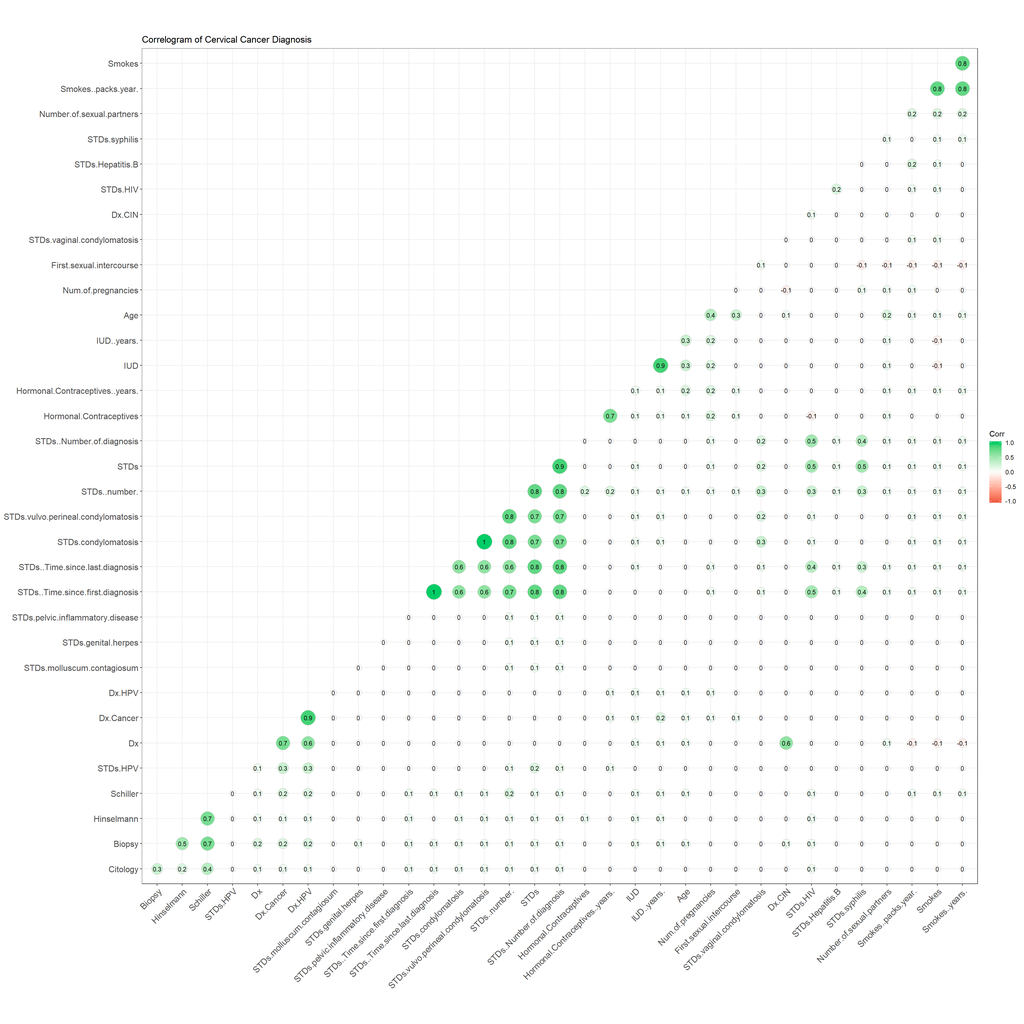

Diagnosis of cancer is highly correlated with HPV, which is well known in the clinics. 20 variables showing correlation less than 0.02 to the diagnosis of Cancer (Dx.Cancer). These variables can be removed. We are going to continue with data as it is, until we build our first model and quntify its performance. Then we will decide to remove some attributes or not.

At the end of this session we will plot two of the correlated measures to cancer to have a visualized overview.

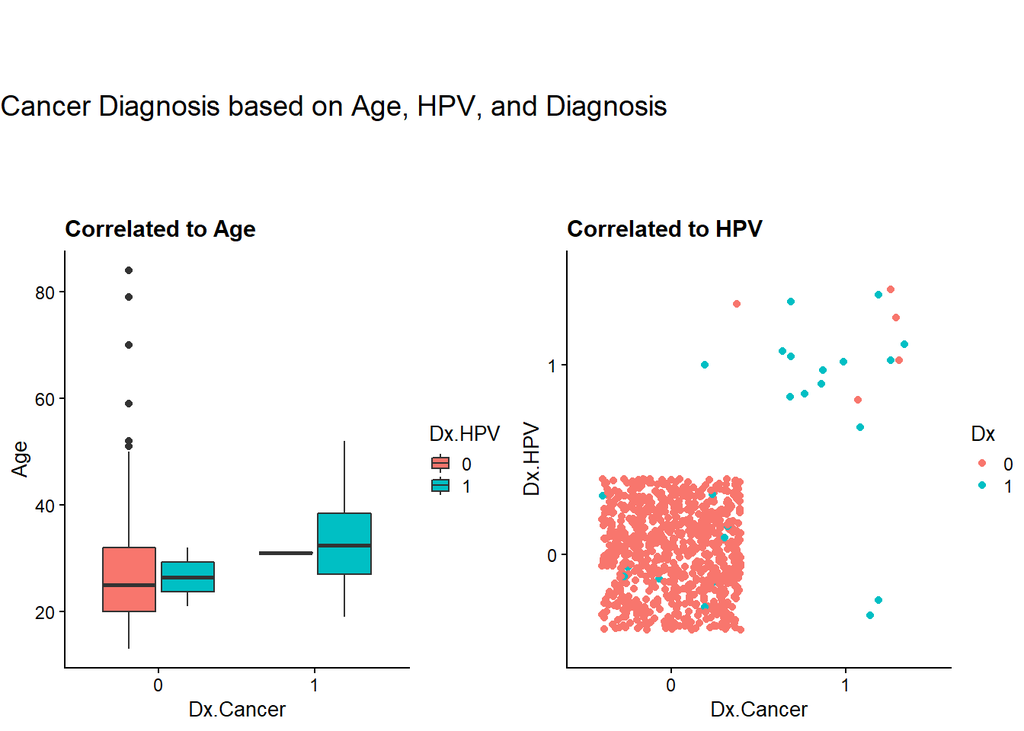

Corresponding to the age, we can say that all patients older than 55 years old are negative to cervical cancer. As shown in correlation plot, there is a strong correlation between HPV infection and cervical cancer.

## Modeling

To work easier let’s bring the dependent variable to the beginning of the data frame.

```r
imputed_data <- imputed_data %>% select(Dx.Cancer, everything())
```

We divide the data to training and testing sets.

```r
set.seed(331)

intrain <- createDataPartition(y = imputed_data[,1], p = 0.8)[[1]]
training <- imputed_data[intrain,]
validation <- imputed_data[-intrain,]

rm(intrain)
```

Now, we will model a gradient boost. Since our data set is relatively small, we apply cross validation as train control.

```r
registerDoParallel(cores = 3)

set.seed(171)

# 5-fold classification
trctrl <- trainControl(method = "cv", number = 5)

# train elastic net model
gbFit <- train(Dx.Cancer ~., data = imputed_data,
               method = "xgbTree",
               trControl = trctrl,
               # other parameters
               tuneGrid = data.frame(nrounds = 200, eta = c(0.05, 0.1, 0.3),
                                     max_depth = 4, gamma = 0, colsample_bytree = 1, subsample = 0.5,
                                     min_child_weight = 1))

stopImplicitCluster()
```

```r
gbFit$bestTune
```

```
##   nrounds max_depth eta gamma colsample_bytree min_child_weight subsample
## 3     200         4 0.3     0                1                1       0.5
```

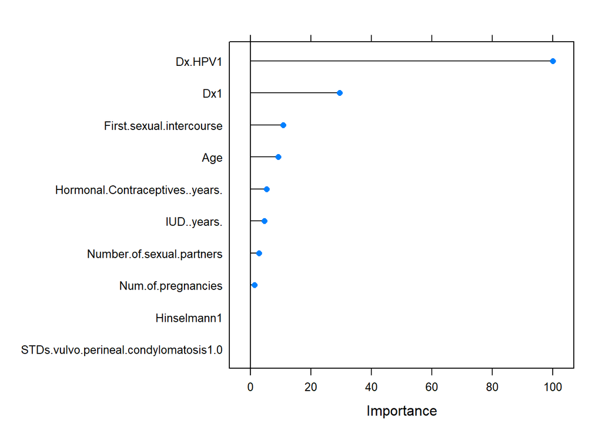

```r
plot(varImp(gbFit), top = 10)
```

As shown above, HPV is the most criteria for diagnosis and prediction of Cervical Cancer, as expected.

```r
class.res <- predict(gbFit, validation[,-1])
confusionMatrix(validation[,1], class.res)$overall[1]
```

```
## Accuracy
##        1
```